# Insurance Charges Prediction

## Insurance Charges Prediction

Problem - 2 Medical Analysis 1. Understand the Data 2. Do proper Diagonistics of the Data 3. Prepare reporg in Tableau based on the Inisghts gather from the data 4. Perform EDA on the dataset 5. Build the Model to accurately predict the charges 6. Show proper model diagonistics for validations. 7. Share the Html file on mail. 8. Upload it in the Github #################################################### Columns age: age of primary beneficiary sex: insurance contractor gender, female, male bmi: Body mass index, providing an understanding of body, weights that are relatively high or low relative to height, objective index of body weight (kg / m ^ 2) using the ratio of height to weight, ideally 18.5 to 24.9 children: Number of children covered by health insurance / Number of dependents smoker: Smoking region: the beneficiary's residential area in the US, northeast, southeast, southwest, northwest. charges: Individual medical costs billed by health insurance ############## Objective ############# Can you accurately predict insurance costs?

Tableau Link: https://public.tableau.com/views/InsuranceCharges_16849470164730/InsuranceCharges?:language=en-US&publish=yes&:display_count=n&:origin=viz_share_link

```python
### Import packages
import pandas as pd
import seaborn as sns
import matplotlib.pyplot as plt
import numpy as np
import math as m
from sklearn.preprocessing import LabelEncoder,StandardScaler,MinMaxScaler,RobustScaler,PolynomialFeatures
from sklearn.model_selection import train_test_split
from sklearn.linear_model import LinearRegression,Ridge,Lasso
from sklearn.metrics import r2_score,mean_squared_error
```

```python
path = "H:/COLLEGE WORKS/DATA SCIENCE/Top Mentors/Materials/Python/Regression Exercise/Regression Assignments"
data = pd.read_csv(path+"/insurance.csv")
```

```python
data.head()
```

|  | age | sex | bmi | children | smoker | region | charges |
| --- | --- | --- | --- | --- | --- | --- | --- |
| 0 | 19 | female | 27.900 | 0 | yes | southwest | 16884.92400 |
| 1 | 18 | male | 33.770 | 1 | no | southeast | 1725.55230 |
| 2 | 28 | male | 33.000 | 3 | no | southeast | 4449.46200 |
| 3 | 33 | male | 22.705 | 0 | no | northwest | 21984.47061 |
| 4 | 32 | male | 28.880 | 0 | no | northwest | 3866.85520 |

```python
### Drive into data
data.columns
```

```
Index(['age', 'sex', 'bmi', 'children', 'smoker', 'region', 'charges'], dtype='object')
```

```python
data.info()
```

```
<class 'pandas.core.frame.DataFrame'>
RangeIndex: 1338 entries, 0 to 1337
Data columns (total 7 columns):
 #   Column    Non-Null Count  Dtype
---  ------    --------------  -----
 0   age       1338 non-null   int64
 1   sex       1338 non-null   object
 2   bmi       1338 non-null   float64
 3   children  1338 non-null   int64
 4   smoker    1338 non-null   object
 5   region    1338 non-null   object
 6   charges   1338 non-null   float64
dtypes: float64(2), int64(2), object(3)
memory usage: 73.3+ KB
```

```python
data.shape
```

```
(1338, 7)
```

```python
data.describe()
```

|  | age | bmi | children | charges |
| --- | --- | --- | --- | --- |
| count | 1338.000000 | 1338.000000 | 1338.000000 | 1338.000000 |
| mean | 39.207025 | 30.663397 | 1.094918 | 13270.422265 |
| std | 14.049960 | 6.098187 | 1.205493 | 12110.011237 |
| min | 18.000000 | 15.960000 | 0.000000 | 1121.873900 |
| 25% | 27.000000 | 26.296250 | 0.000000 | 4740.287150 |
| 50% | 39.000000 | 30.400000 | 1.000000 | 9382.033000 |
| 75% | 51.000000 | 34.693750 | 2.000000 | 16639.912515 |
| max | 64.000000 | 53.130000 | 5.000000 | 63770.428010 |

```python
data.dtypes
```

```
age           int64
sex          object
bmi         float64
children      int64
smoker       object
region       object
charges     float64
dtype: object
```

```python
data['age'].unique()
```

```
array([19, 18, 28, 33, 32, 31, 46, 37, 60, 25, 62, 23, 56, 27, 52, 30, 34,
       59, 63, 55, 22, 26, 35, 24, 41, 38, 36, 21, 48, 40, 58, 53, 43, 64,
       20, 61, 44, 57, 29, 45, 54, 49, 47, 51, 42, 50, 39], dtype=int64)
```

```python
data['age'].nunique()
```

```
47
```

```python
data['sex'].value_counts()
```

```
male      676
female    662
Name: sex, dtype: int64
```

```python
data['children'].nunique()
```

```
6
```

```python
data['children'].value_counts()
```

```
0    574
1    324
2    240
3    157
4     25
5     18
Name: children, dtype: int64
```

```python
data['smoker'].value_counts()
```

```
no     1064
yes     274
Name: smoker, dtype: int64
```

```python
data['region'].value_counts()
```

```
southeast    364
southwest    325
northwest    325
northeast    324
Name: region, dtype: int64
```

```python
data.isnull().sum()
### No null values
```

```
age         0
sex         0
bmi         0
children    0
smoker      0
region      0
charges     0
dtype: int64
```

```python
data[data.duplicated()]
```

|  | age | sex | bmi | children | smoker | region | charges |
| --- | --- | --- | --- | --- | --- | --- | --- |
| 581 | 19 | male | 30.59 | 0 | no | northwest | 1639.5631 |

```python
### removing the duiplicated data from the data frame
data.drop(index=581,axis=1,inplace=True)
```

```python
data.describe()
### Now also no big difference in the data informations
```

|  | age | bmi | children | charges |
| --- | --- | --- | --- | --- |
| count | 1337.000000 | 1337.000000 | 1337.000000 | 1337.000000 |
| mean | 39.222139 | 30.663452 | 1.095737 | 13279.121487 |
| std | 14.044333 | 6.100468 | 1.205571 | 12110.359656 |
| min | 18.000000 | 15.960000 | 0.000000 | 1121.873900 |
| 25% | 27.000000 | 26.290000 | 0.000000 | 4746.344000 |
| 50% | 39.000000 | 30.400000 | 1.000000 | 9386.161300 |
| 75% | 51.000000 | 34.700000 | 2.000000 | 16657.717450 |
| max | 64.000000 | 53.130000 | 5.000000 | 63770.428010 |

```python
data.head()

lb_sex = LabelEncoder()
data['sex'] = lb_sex.fit_transform(data['sex'])

data['sex']

lb_sex.inverse_transform(data['sex'])
```

```
array(['female', 'male', 'male', ..., 'female', 'female', 'female'],
      dtype=object)
```

```python
lb_smoker = LabelEncoder()
data['smoker'] = lb_smoker.fit_transform(data['smoker'])

data['smoker']

#lb_smoker.inverse_transform(data['smoker'])
```

```
0       1
1       0
2       0
3       0
4       0
       ..
1333    0
1334    0
1335    0
1336    0
1337    1
Name: smoker, Length: 1337, dtype: int32
```

```python
lb_region = LabelEncoder()
data['region'] = lb_region.fit_transform(data['region'])

data['region']
#lb_region.inverse_transform(data['region'])
```

```
0       3
1       2
2       2
3       1
4       1
       ..
1333    1
1334    0
1335    2
1336    3
1337    1
Name: region, Length: 1337, dtype: int32
```

```python
data.head()
```

|  | age | sex | bmi | children | smoker | region | charges |
| --- | --- | --- | --- | --- | --- | --- | --- |
| 0 | 19 | 0 | 27.900 | 0 | 1 | 3 | 16884.92400 |
| 1 | 18 | 1 | 33.770 | 1 | 0 | 2 | 1725.55230 |
| 2 | 28 | 1 | 33.000 | 3 | 0 | 2 | 4449.46200 |
| 3 | 33 | 1 | 22.705 | 0 | 0 | 1 | 21984.47061 |
| 4 | 32 | 1 | 28.880 | 0 | 0 | 1 | 3866.85520 |

```python
### Now all the columns have been changed to numerical dtype
data.dtypes
```

```
age           int64
sex           int32
bmi         float64
children      int64
smoker        int32
region        int32
charges     float64
dtype: object
```

```python
scalar = StandardScaler()
data_scaled = scalar.fit_transform(data)
data_scaled_df = pd.DataFrame(data_scaled,columns=data.columns)
data_scaled_df
```

|  | age | sex | bmi | children | smoker | region | charges |
| --- | --- | --- | --- | --- | --- | --- | --- |
| 0 | -1.440418 | -1.009771 | -0.453160 | -0.909234 | 1.969660 | 1.343163 | 0.297857 |
| 1 | -1.511647 | 0.990324 | 0.509422 | -0.079442 | -0.507702 | 0.438017 | -0.954381 |
| 2 | -0.799350 | 0.990324 | 0.383155 | 1.580143 | -0.507702 | 0.438017 | -0.729373 |
| 3 | -0.443201 | 0.990324 | -1.305052 | -0.909234 | -0.507702 | -0.467128 | 0.719104 |
| 4 | -0.514431 | 0.990324 | -0.292456 | -0.909234 | -0.507702 | -0.467128 | -0.777499 |
| ... | ... | ... | ... | ... | ... | ... | ... |
| 1332 | 0.767704 | 0.990324 | 0.050269 | 1.580143 | -0.507702 | -0.467128 | -0.221263 |
| 1333 | -1.511647 | -1.009771 | 0.206053 | -0.909234 | -0.507702 | -1.372274 | -0.914695 |
| 1334 | -1.511647 | -1.009771 | 1.014490 | -0.909234 | -0.507702 | 0.438017 | -0.962287 |
| 1335 | -1.297958 | -1.009771 | -0.797524 | -0.909234 | -0.507702 | 1.343163 | -0.931054 |
| 1336 | 1.551231 | -1.009771 | -0.261299 | -0.909234 | 1.969660 | -0.467128 | 1.310298 |

1337 rows × 7 columns

#### Exploratory data analysis

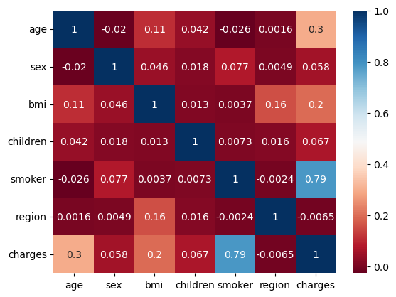

```python
sns.heatmap(data=data.corr(),annot=True,cmap='RdBu')
```

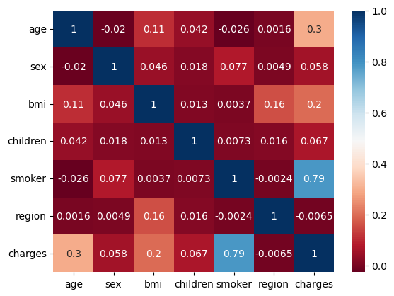

```python
sns.heatmap(data=data_scaled_df.corr(),annot=True,cmap='RdBu')
```

```python
data_southeast = data[data['region'] == 0]
```

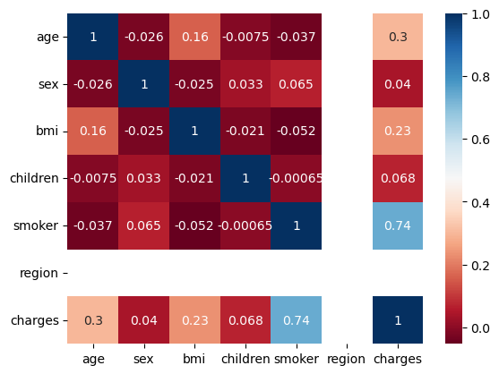

```python
sns.heatmap(data=data_southeast.corr(),annot=True,cmap='RdBu')
```

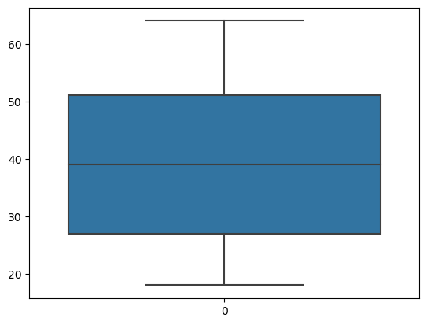

```python
sns.boxplot(data['age'])
```

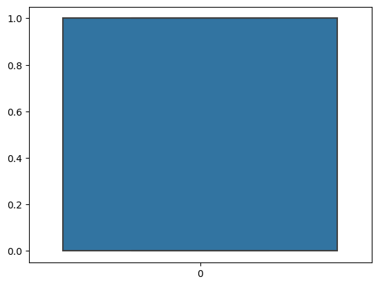

```python
sns.boxplot(data['sex'])
```

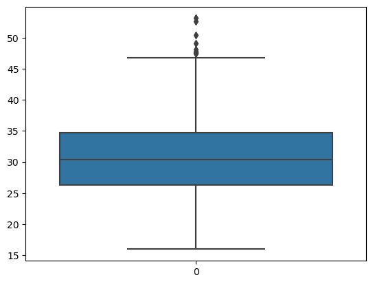

```python
sns.boxplot(data['bmi'])
```

```python
### so bmi has outliers we need to treat them
```

```python
def treat_outliers(data):
    q3 = np.percentile(data,75)
    q1 = np.percentile(data,25)
    iqr = q3 - q1
    upper = q3 + (1.5 * iqr)
    lower = q1 - (1.5 * iqr)
    for i in range(0,len(data)):
        if data[i] > upper:
            data[i] = upper
        elif data[i] < lower:
            data[i] = lower
    return data
```

```python
data['bmi'] = treat_outliers(data['bmi'].values)
```

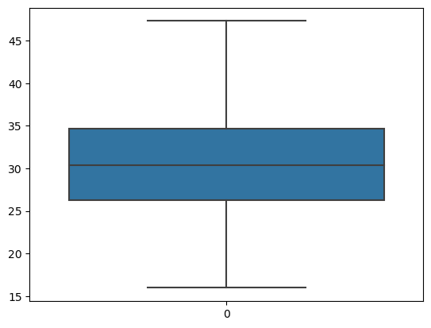

```python
sns.boxplot(data['bmi'])
```

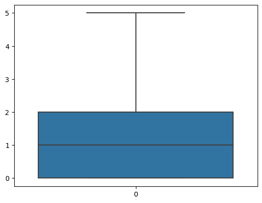

```python
sns.boxplot(data['children'])
```

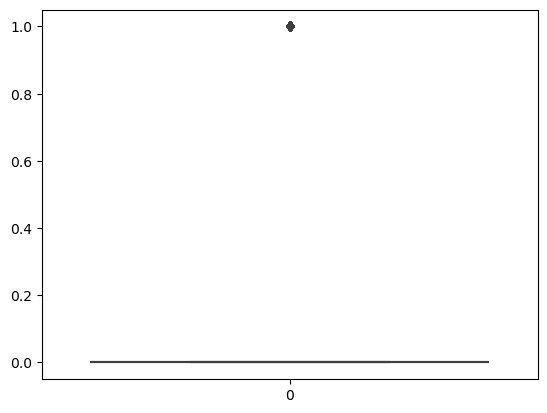

```python
sns.boxplot(data['smoker'])
```

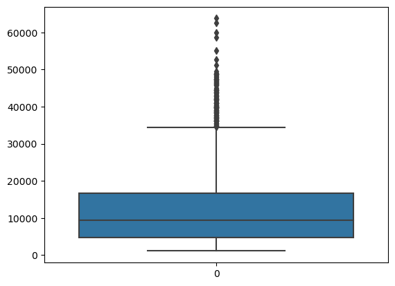

```python
sns.boxplot(data['charges'])
```

```python
data['charges'] = treat_outliers(data['charges'].values)
```

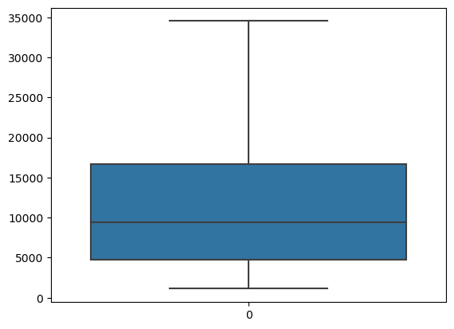

```python
sns.boxplot(data['charges'])
```